# Evaluatie soortenmeetnetten 2018

Toon Westra

17 december 2018

# 1 Inleiding

In dit rapport geven we een overzicht van de uitgevoerde tellingen in kader van de soortenmeetnetten en maken we een verkenning van de ingevoerde aantallen.

# 2 Amfibieën

## 2.1 Meetnetkarakteristieken

Tabel 2.1 en Tabel 2.2 geven een overzicht van de karakteristieken van de amfibieënmeetnetten.

Tabel 2.1: Overzicht van de karakteristieken van de amfibieënmeetnetten: veldprotocol, type meetnet (integraal of steekproef), aantal meetnetlocaties en de meetcyclus in jaren

| Meetnet | Protocol | Type | Meetnetlocaties | Meetcyclus (jaar) | Start |
| --- | --- | --- | --- | --- | --- |
| Boomkikker | Padden en kikkers - Roepkoren | Steekproef | 60 | 3 | 2016 |
| Boomkikker | Amfibieën - Larven en metamorfen | Steekproef | 60 | 3 | 2016 |
| Kamsalamander | Amfibieën - Fuiken | Steekproef | 60 | 3 | 2017 |
| Kamsalamander | Amfibieën - Larven en metamorfen | Steekproef | 60 | 3 | 2017 |
| Knoflookpad | Padden en kikkers - Roepkoren | Integraal | 6 | 1 | 2017 |
| Knoflookpad | Amfibieën - Larven en metamorfen | Integraal | 6 | 1 | 2017 |
| Vuursalamander | Vuursalamander - Transecten | Integraal | 38 | 1 | 2016 |
| Rugstreeppad | Rugstreeppad - Roepkoren of zichtwaarneming | Integraal | 47 | 3 | 2018 |

Tabel 2.2: Overzicht van de karakteristieken van de amfibieënmeetnetten: aantal bezoeken per jaar, begin en einde van de telperiode

| Meetnet | Protocol | Bezoeken (/jaar) | Begin telperiode | Einde telperiode |
| --- | --- | --- | --- | --- |
| Boomkikker | Padden en kikkers - Roepkoren | 2 | 15/apr | 15/jun |
|  | Amfibieën - Larven en metamorfen | 1 | 1/jul | 30/jul |
| Kamsalamander | Amfibieën - Fuiken | 2 | 15/apr | 31/mei |
|  | Amfibieën - Larven en metamorfen | 1 | 1/jul | 15/jul |
| Knoflookpad | Padden en kikkers - Roepkoren | 2 | 1/apr | 30/apr |
|  | Amfibieën - Larven en metamorfen | 1 | 15/mei | 30/jun |
| Vuursalamander | Vuursalamander - Transecten | 2 | 1/sep | 30/okt |
| Rugstreeppad | Rugstreeppad - Roepkoren of zichtwaarneming | 4 |  |  |

## 2.2 Overzicht van de uitgevoerde tellingen

### 2.2.1 Aantal tellingen en aantal getelde locaties

In bijlage 5.1 wordt per meetnetloctie een overzicht gegeven van de uitgevoerde taken.

Tabel 2.3 geeft een overzicht van de meetnetten waarvan de locaties jaarlijks worden geteld (de meetcyclus is dus 1 jaar). In de tabel onderscheiden we:

- de jaardoelen: het aantal te tellen locaties voor een bepaald jaar;
- het aantal tellingen conform protocol;
- het aantal tellingen dat niet kon worden uitgevoerd door overmacht; en
- het aantal voldoende getelde meetnetlocaties: dit zijn de locaties waar het aantal tellingen werd gehaald binnen de afgesproken telperiode, conform het protocol. Ook de tellingen die niet konden uitgevoerd worden door overmacht worden hiervoor meegrekend.

Tabel 2.3: Overzicht van de tellingen voor de amfibiemeetnetten met 1-jarige meetcyclus en de vooropgestelde doelen

| Meetnet | Protocol | Jaar | Jaardoel | Tellingen conform protocol | Tellingen niet uitvoerbaar | Meetnetlocaties voldoende geteld - totaal |
| --- | --- | --- | --- | --- | --- | --- |
| Knoflookpad | Padden en kikkers - Roepkoren | 2017 | 4 locaties | 12 | 0 | 4 |
|  |  | 2018 | 4 locaties | 15 | 0 | 5 |
| Vuursalamander | Vuursalamander - Transecten | 2016 | 20 locaties | 85 | 1 | 37 |
|  |  | 2017 | 35 locaties | 101 | 0 | 39 |
|  |  | 2018 | 34 locaties | 93 | 0 | 39 |

Tabel 2.4 geeft een overzicht van de meetnetten met een meetcyclus van 3 jaar. De tabel geeft volgende bijkomende informatie:

- de doelen voor de meetcyclus: het aantal te tellen locaties voor de volledige meetcyclus;
- de nieuwe getelde meetnetlocaties: de locaties die voor een eerste maal (voldoende) werden geteld binnen de meetcyclus;
- het totaal aantal getelde locaties binnen een meetcyclus.

Tabel 2.4: Overzicht van de tellingen voor de amfibiemeetnetten met 3-jarige meetcyclus en de vooropgestelde doelen

| Meetnet | Protocol | Jaar | Jaardoel | Doel meetcyclus | Tellingen conform protocol | Tellingen niet uitvoerbaar | Meetnetlocaties voldoende geteld - totaal | Meetnetlocaties voldoende geteld - nieuw | Meetnetlocaties voldoende geteld - cyclus |
| --- | --- | --- | --- | --- | --- | --- | --- | --- | --- |
| Boomkikker | Amfibieën - Larven en metamorfen | 2016 | 20 locaties | 60 locaties | 35 | 0 | 35 | 35 | 55 |
|  |  | 2017 | 12 nieuwe locaties | 60 locaties | 13 | 0 | 13 | 4 | 55 |
|  |  | 2018 | 12 nieuwe locaties | 60 locaties | 21 | 0 | 20 | 16 | 55 |
|  | Padden en kikkers - Roepkoren | 2016 | 20 locaties | 60 locaties | 68 | 0 | 26 | 26 | 58 |
|  |  | 2017 | 12 nieuwe locaties | 60 locaties | 44 | 0 | 15 | 9 | 58 |
|  |  | 2018 | 12 nieuwe locaties | 60 locaties | 59 | 0 | 28 | 23 | 58 |
| Kamsalamander | Amfibieën - Fuiken | 2017 | 12 nieuwe locaties | 60 locaties | 28 | 20 | 18 | 18 | 52 |
|  |  | 2018 | 12 nieuwe locaties | 60 locaties | 81 | 0 | 36 | 34 | 52 |
|  | Amfibieën - Larven en metamorfen | 2017 | 12 nieuwe locaties | 60 locaties | 4 | 15 | 18 | 18 | 37 |
|  |  | 2018 | 12 nieuwe locaties | 60 locaties | 19 | 0 | 19 | 19 | 37 |
| Rugstreeppad | Rugstreeppad - Roepkoren of zichtwaarneming | 2018 | 8 locaties | 47 locaties | 33 | 0 | 2 | 2 | 2 |

Tabel 2.5 geeft een overzicht de tellingen voor extra locaties die niet tot de steekproef behoren.

Tabel 2.5: Overzicht van de tellingen voor extra locaties die niet tot de steekproef behoren

| Meetnet | Protocol | Jaar | Tellingen conform protocol | Tellingen niet uitvoerbaar | Extra locaties voldoende geteld - totaal | Extra locaties voldoende geteld - nieuw | Extra locaties voldoende geteld - cyclus |
| --- | --- | --- | --- | --- | --- | --- | --- |
| Boomkikker | Amfibieën - Larven en metamorfen | 2016 | 0 | 0 | 0 | 0 | 15 |
|  |  | 2017 | 12 | 1 | 13 | 13 | 15 |
|  |  | 2018 | 5 | 0 | 4 | 2 | 15 |
|  | Padden en kikkers - Roepkoren | 2016 | 0 | 0 | 0 | 0 | 13 |
|  |  | 2017 | 37 | 0 | 11 | 11 | 13 |
|  |  | 2018 | 4 | 0 | 2 | 2 | 13 |
| Kamsalamander | Amfibieën - Fuiken | 2017 | 41 | 0 | 14 | 14 | 16 |
|  |  | 2018 | 8 | 0 | 4 | 2 | 16 |
|  | Amfibieën - Larven en metamorfen | 2017 | 4 | 4 | 8 | 8 | 11 |
|  |  | 2018 | 4 | 0 | 4 | 3 | 11 |

### 2.2.2 Tijdstippen van de tellingen

Figuur 2.1 geeft een overzicht van de tijdstippen van de bezoeken.

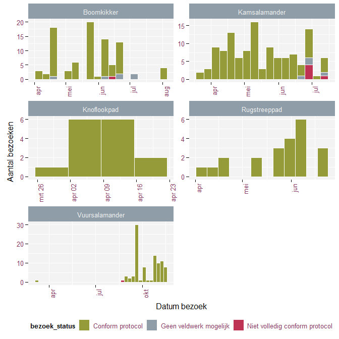

### 2.2.3 Afwijkingen van het protocol

De volgende tabel geeft een overzicht van de afwijkingen van het protocol (TellingCP = Telling conform protocol, TellingNVCP = Telling niet volledig conform protocol, TellingGVM = Geen veldwerk mogelijk).

| meetnet | datum | locatie | bezoek status | opmerkingen |
| --- | --- | --- | --- | --- |
| Boomkikker | 2018-04-19 | Gouvernement polder | Geen veldwerk mogelijk | Geen geschikt habitat meer. Geen water meer door werken. |
| Boomkikker | 2018-06-08 | Gouvernement polder | Geen veldwerk mogelijk | Geen water meer. Geen geschikt habitat meer. |
| Boomkikker | 2018-06-18 | Gouvernement polder | Geen veldwerk mogelijk | De put is volledig overgroeid |
| Boomkikker | 2018-07-04 | Opitter 1 | Geen veldwerk mogelijk | Niet mogelijk te scheppen in de dicht begroeide vijvers. |
| Boomkikker | 2018-07-04 | Opitter 2 | Geen veldwerk mogelijk | Niet mogelijk te scheppen in de dicht begroeide vijvers. |
| Boomkikker | 2018-06-12 | Sint-Maartensheide Zuid - Poel 1 | Niet volledig conform protocol | Te weinig water om te scheppen ; |
| Boomkikker | 2018-06-18 | Zwin - Kleine vlakte 6 | Geen veldwerk mogelijk | De poel was volledig begroeid waardoor scheppen niet mogelijk was |
| Kamsalamander | 2018-06-18 | Het Zwin 1 | Geen veldwerk mogelijk | Door de hoeveelheid planten is scheppen niet mogelijk. |
| Kamsalamander | 2018-06-25 | Kerkstraat 1 | Geen veldwerk mogelijk | Droog gevallen |
| Kamsalamander | 2018-06-30 | Kooldries Hoofsweer - Poel 26 | Geen veldwerk mogelijk | deze poel was volledig droog gevallen . |
| Kamsalamander | 2018-06-30 | Kooldries - Poel 11 | Niet volledig conform protocol | Deze poel had nog een grote oppervlakte water , doch doordat er een 1/2 meter hoofdzakelijk bladslib in zit is het praktisch onmogelijk om te scheppen , we hebben dit toch getracht met een klein schep… |
| Kamsalamander | 2018-06-29 | Kooldries - Poel 30 | Niet volledig conform protocol | Het waterpeil was zodanig laag dat er slechts in het midden van de poel op een kleine oppervlakte kon geschept worden . |
| Kamsalamander | 2018-07-10 | Tommelen - Poel 2 | Geen veldwerk mogelijk | plas volledig verdroogd. geen ml water meer te bespeuren. |
| Kamsalamander | 2018-07-10 | Tommelen - Poel 6 | Niet volledig conform protocol | mooie waterplanten restanten maar sterk aan het verlanden en weinig xater waardoor scheppen nagenoeg onmogelijk was. Sterk aan het vergrassen en algen. |
| Kamsalamander | 2018-06-28 | Wijgmaalbroek - Poel 1 | Niet volledig conform protocol | poel was al uitgedroogd |
| Kamsalamander | 2018-06-28 | Wijgmaalbroek - Poel 3 | Niet volledig conform protocol | Er staat oa lisdodde in de poel waardoor er niet volledig rondom de poel kan geschept worden |
| Vuursalamander | 2018-08-23 | Bos Terrijst | Niet volledig conform protocol | Eerste poging van het najaar, net voor zonsondergang lichte regen waardoor de vochtigheid vrij hoog was. Geen toptelling, maar goed om er in te komen. Op ‘niet conform protocol’ gezet aangezien tellin… |

## 2.3 Verkenning van de ingevoerde aantallen

### 2.3.1 Kikkers en padden

#### 2.3.1.1 Verdeling getelde aantallen per bezoek

Onderstaande figuren tonen de verdeling van de getelde aantallen per bezoek.

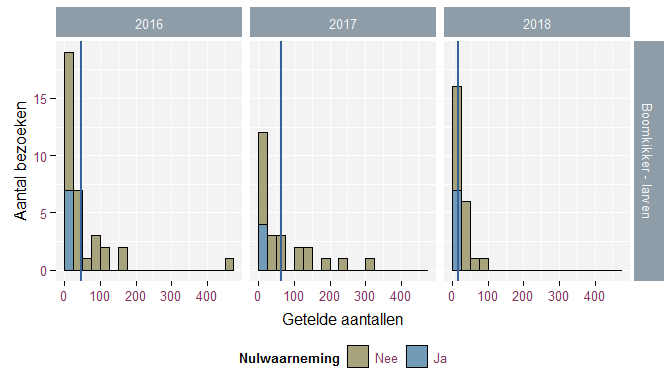

Figuur 2.2: Verdeling van totaal getelde aantallen per bezoek - Boomkikker - larven

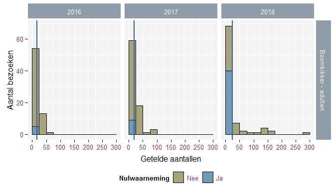

Figuur 2.2: Verdeling van totaal getelde aantallen per bezoek - Boomkikker - adulten

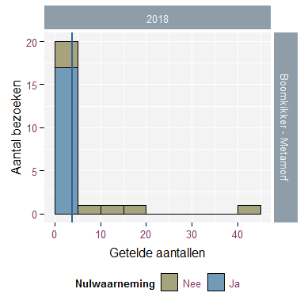

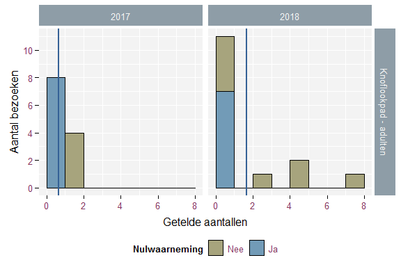

Figuur 2.3: Verdeling van totaal getelde aantallen per bezoek - Knoflookpad - adulten

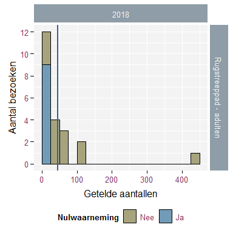

Figuur 2.4: Verdeling van totaal getelde aantallen per bezoek - Rugstreeppad - adulten

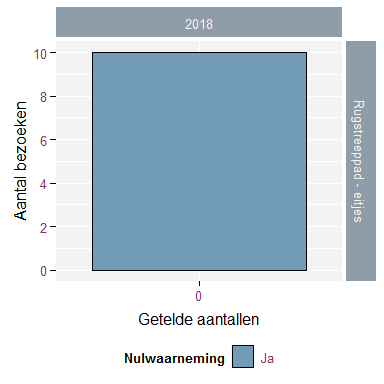

Figuur 2.4: Verdeling van totaal getelde aantallen per bezoek - Rugstreeppad - eitjes

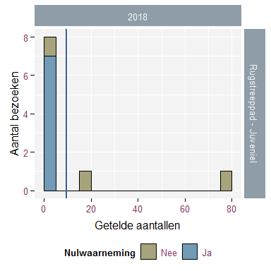

Figuur 2.4: Verdeling van totaal getelde aantallen per bezoek - Rugstreeppad - Juveniel

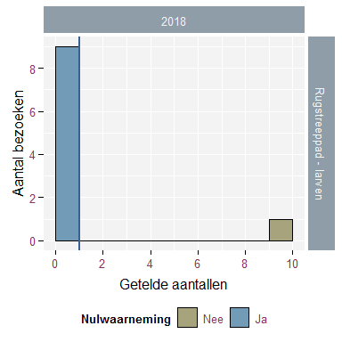

Figuur 2.4: Verdeling van totaal getelde aantallen per bezoek - Rugstreeppad - larven

#### 2.3.1.2 Evolutie getelde aantallen binnen telperiode

Onderstaande figuren geven de evolutie van de getelde aantallen binnen het seizoen. De stippelijnen verbinden tellingen van eenzelfde locatie. De blauwe lijn toont de gemiddelde evolutie binnen het seizoen, waarbij de grijze banden aan beide kanten van de blauwe lijn de onzekerheid aangeven op deze gemiddelde evolutie.

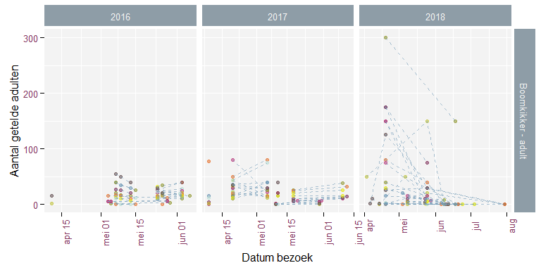

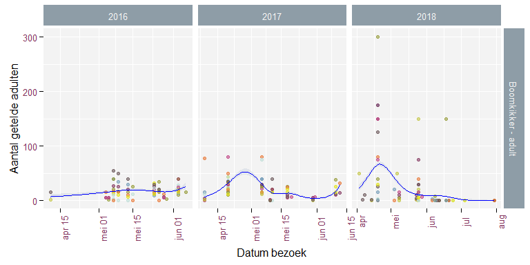

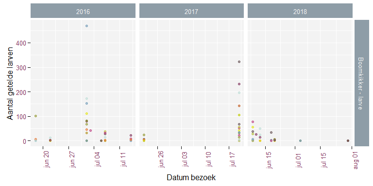

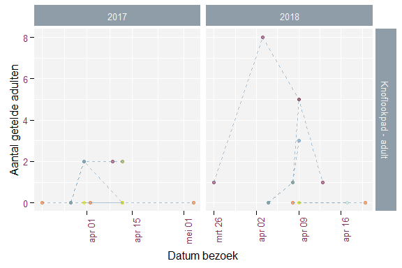

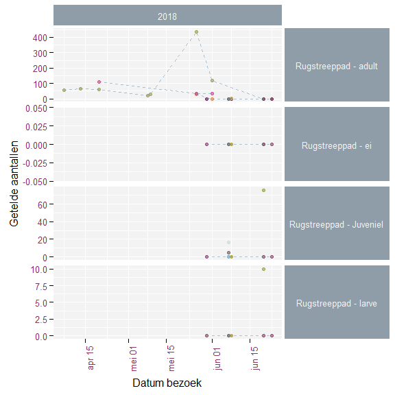

#### 2.3.1.3 Evolutie gemiddelde aantallen per locatie en per jaar

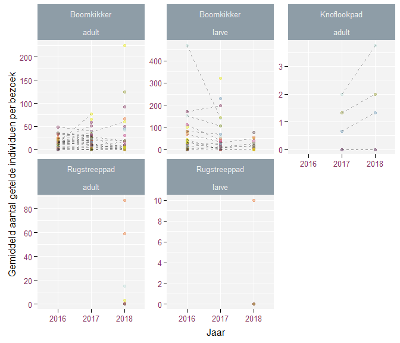

Figuur 2.5: Gemiddeld aantal getelde individuen per locatie en per jaar

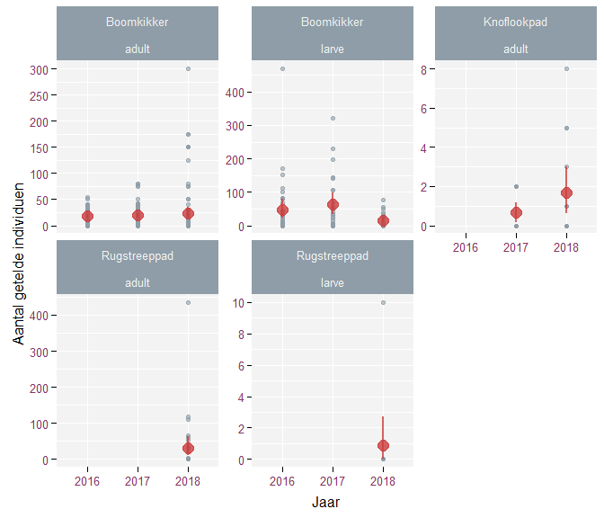

Figuur 2.6: Gemiddeld aantal getelde individuen per jaar met 95%-betrouwbaarheidsinterval (rood) en aantal getelde individuen per bezoek (grijs)

### 2.3.2 Salamanders

#### 2.3.2.1 Aantal fuikvangsten Kamsalamander per bezoek

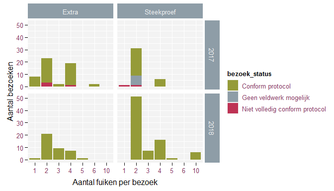

#### 2.3.2.2 Verdeling getelde aantallen per bezoek

Onderstaande figuren tonen de verdeling van de getelde aantallen per bezoek.

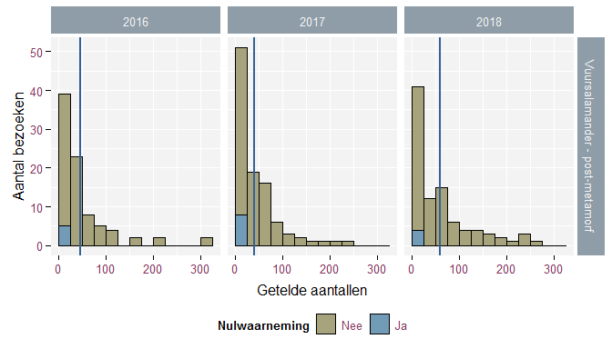

Figuur 2.8: Verdeling van totaal getelde aantallen per bezoek - Vuursalamander - post-metamorf

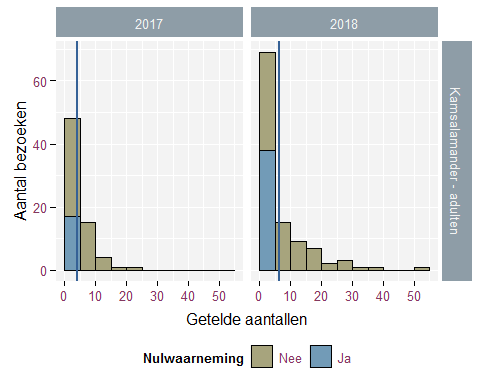

Figuur 2.9: Verdeling van totaal getelde aantallen per bezoek - Kamsalamander - adulten

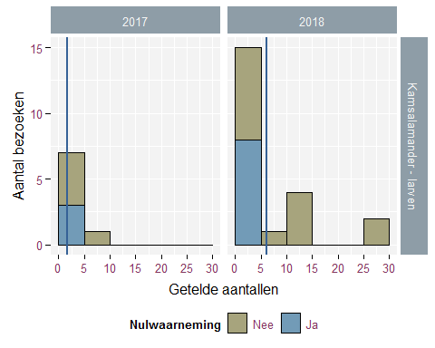

Figuur 2.9: Verdeling van totaal getelde aantallen per bezoek - Kamsalamander - larven

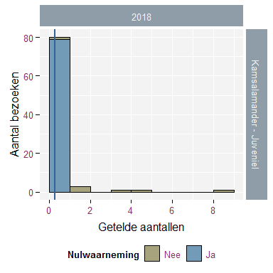

Figuur 2.10: Verdeling van totaal getelde aantallen per bezoek - Kamsalamander - Juveniel

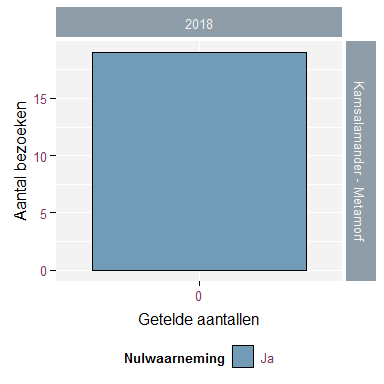

Figuur 2.10: Verdeling van totaal getelde aantallen per bezoek - Kamsalamander - Metamorf

#### 2.3.2.3 Evolutie getelde aantallen binnen telperiode

Onderstaande figuren geven de evolutie van de getelde aantallen binnen het seizoen. De stippelijnen verbinden tellingen van eenzelfde locatie. De blauwe lijn toont de gemiddelde evolutie binnen het seizoen, waarbij de grijze banden aan beide kanten van de blauwe lijn de onzekerheid aangeven op deze gemiddelde evolutie.

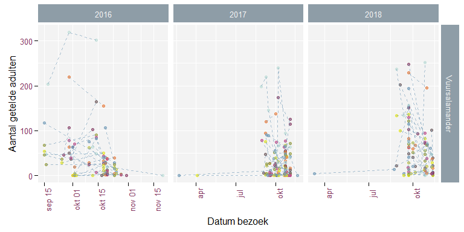

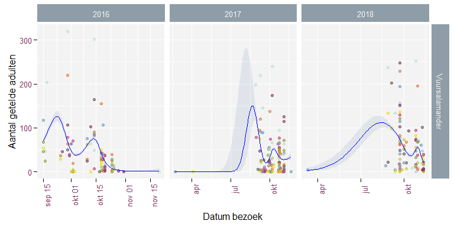

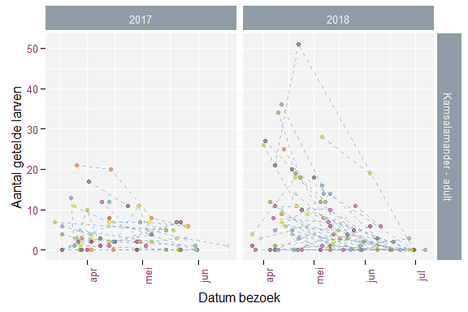

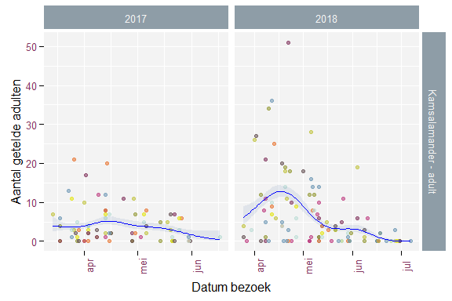

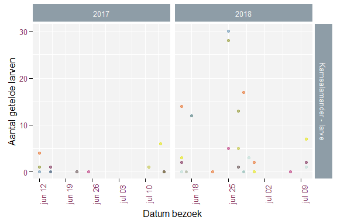

#### 2.3.2.4 Evolutie gemiddelde aantallen per locatie en per jaar

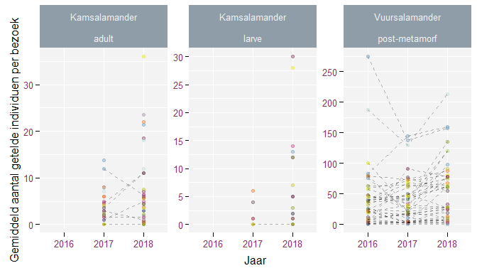

Figuur 2.11: Gemiddeld aantal getelde individuen per locatie en per jaar

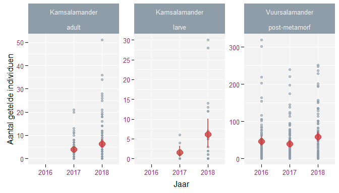

Figuur 2.12: Gemiddeld aantal getelde individuen per jaar met 95%-betrouwbaarheidsinterval (rood) en aantal getelde individuen per bezoek (grijs)

## 2.4 Verkenning ingevoerde waarden voor de kwaliteit van het leefgebied

Om de kwaliteit van het leefgebied van de Boomkikker en de Kamsalamander te beoordelen bepalen de vrijwilligers voor elke poel in het meetnet volgende karakteristieken:

- aanwezigheid vis,
- beschaduwing,
- permanente waterkolom,
- waterkwaliteit,
- pH,
- maximale diepte poel,
- oppervlakte poel.

2.13 toont de karakteristieken die worden ingeschat a.d.h.v. een aantal vaste categorieën waaruit de vrijwilliger een selectie moet maken. We zien dat er nog vaak ‘Onbekend’ wordt ingegeven voor de karakteristieken. Mogelijks kan dit verholpen worden door duidelijkere richtlijnen op te nemen in de handleiding over hoe de karakteristieken bepaald moeten worden.

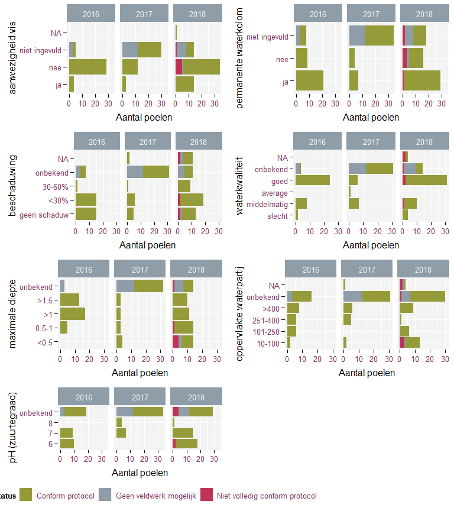

Figuur 2.13: Overzicht van ingevoerde waarden voor de verschillende indiatoren voor de kwaliteit van het leefgebied

# 3 Libellen

## 3.1 Meetnetkarakteristieken

Tabel 3.1 en Tabel 3.2 geven een overzicht van de karakteristieken van de libellenmeetnetten (De Knijf et al.2015).

Tabel 3.1: Overzicht van de karakteristieken van de libellenmeetnetten: veldprotocol, type meetnet (integraal of steekproef), aantal meetnetlocaties en de meetcyclus in jaren

| Meetnet | Protocol | Type | Meetnetlocaties | Meetcyclus (jaar) | Start |
| --- | --- | --- | --- | --- | --- |
| Gevlekte witsnuitlibel | Libellen - Populatietelling per locatie | Integraal | 25 | 1 | 2016 |
| Hoogveenglanslibel | Libellen - Populatietelling per locatie | Integraal | 12 | 1 | 2018 |
| Kempense heidelibel | Libellen - Populatietelling per locatie | Integraal | 6 | 1 | 2016 |
| Maanwaterjuffer | Libellen - Populatietelling per locatie | Integraal | 7 | 1 | 2016 |
| Rivierrombout | Libellen - Larvenhuidjes | Integraal | 13 | 1 | 2016 |
| Beekrombout | Libellen - Larvenhuidjes | Integraal | 11 | 1 | 2018 |
| Speerwaterjuffer | Libellen - Populatietelling per locatie | Integraal | 6 | 1 | 2017 |
| Variabele waterjuffer | Libellen - Transecten | Steekproef | 30 | 3 | 2017 |
| Bosbeekjuffer | Libellen - Transecten | Steekproef | 30 | 3 | 2018 |
| Vroege glazenmaker | Libellen - Transecten | Steekproef | 30 | 3 | 2017 |

Tabel 3.2: Overzicht van de karakteristieken van de libellenmeetnetten: aantal bezoeken per jaar, begin en einde van de telperiode

| Meetnet | Bezoeken (/jaar) | Begin telperiode | Einde telperiode |
| --- | --- | --- | --- |
| Gevlekte witsnuitlibel | 2 | 1/jun | 30/jun |
| Hoogveenglanslibel | 2 | 1/jun | 30/jul |
| Kempense heidelibel | 2 | 1/aug | 31/aug |
| Maanwaterjuffer | 2 | 1/mei | 31/mei |
| Rivierrombout | 5 | 20/jun | 20/aug |
| Beekrombout | 3 |  |  |
| Speerwaterjuffer | 2 | 15/mei | 20/jun |
| Variabele waterjuffer | 2 | 1/mei | 30/jun |
| Bosbeekjuffer | 2 |  |  |
| Vroege glazenmaker | 2 | 1/mei | 30/jun |

## 3.2 Overzicht van de uitgevoerde tellingen

### 3.2.1 Aantal tellingen en aantal getelde locaties

In bijlage 5.3 wordt per meetnetloctie een overzicht gegeven van de uitgevoerde taken.

Tabel 3.3 geeft een overzicht van de meetnetten waarvan de locaties jaarlijks worden geteld (de meetcyclus is dus 1 jaar). In de tabel onderscheiden we:

- de jaardoelen: het aantal te tellen locaties voor een bepaald jaar;
- het aantal tellingen conform protocol;
- het aantal tellingen dat niet kon worden uitgevoerd door overmacht; en
- het aantal voldoende getelde meetnetlocaties: dit zijn de locaties waar het aantal tellingen werd gehaald binnen de afgesproken telperiode, conform het protocol. Ook de tellingen die niet konden uitgevoerd worden door overmacht worden hiervoor meegrekend.

Tabel 3.3: Overzicht van de tellingen voor de libellenmeetnetten met 1-jarige meetcyclus en de vooropgestelde doelen

| Protocol | Meetnet | Jaar | Jaardoel | Tellingen conform protocol | Tellingen niet uitvoerbaar | Meetnetlocaties voldoende geteld - totaal |
| --- | --- | --- | --- | --- | --- | --- |
| Libellen - Larvenhuidjes | Beekrombout | 2018 | 5 locaties | 0 | 0 | 0 |
|  | Rivierrombout | 2016 | 40 bezoeken | 65 | 0 | 10 |
|  |  | 2017 | 10 locaties | 68 | 0 | 11 |
|  |  | 2018 | 10 locaties | 54 | 0 | 6 |
| Libellen - Populatietelling per locatie | Gevlekte witsnuitlibel | 2016 | 15 locaties | 43 | 8 | 24 |
|  |  | 2017 | 20 locaties | 49 | 0 | 23 |
|  |  | 2018 | 20 locaties | 49 | 0 | 21 |
|  | Kempense heidelibel | 2016 | 6 locaties | 12 | 0 | 4 |
|  |  | 2017 | 5 locaties | 13 | 1 | 4 |
|  |  | 2018 | 5 locaties | 13 | 0 | 5 |
|  | Maanwaterjuffer | 2016 | 6 locaties | 19 | 0 | 7 |
|  |  | 2017 | 7 locaties | 16 | 0 | 7 |
|  |  | 2018 | 7 locaties | 15 | 0 | 7 |
|  | Speerwaterjuffer | 2017 | 6 locaties | 10 | 1 | 5 |
|  |  | 2018 | 5 locaties | 13 | 0 | 6 |

Tabel 3.4 geeft een overzicht van de meetnetten met een meetcyclus van 3 jaar. De tabel geeft volgende bijkomende informatie:

- de doelen voor de meetcyclus: het aantal te tellen locaties voor de volledige meetcyclus;
- de nieuwe getelde meetnetlocaties: de locaties die voor een eerste maal (voldoende) werden geteld binnen de meetcyclus;
- het totaal aantal getelde locaties binnen een meetcyclus.

Tabel 3.4: Overzicht van de tellingen voor de libellenmeetnetten met 3-jarige meetcyclus en de vooropgestelde doelen

| Protocol | Meetnet | Jaar | Jaardoel | Doel meetcyclus | Tellingen conform protocol | Tellingen niet uitvoerbaar | Meetnetlocaties voldoende geteld - totaal | Meetnetlocaties voldoende geteld - nieuw | Meetnetlocaties voldoende geteld - cyclus |
| --- | --- | --- | --- | --- | --- | --- | --- | --- | --- |
| Libellen - Transecten | Bosbeekjuffer | 2018 | 6 nieuwe locaties | 30 locaties | 26 | 0 | 9 | 9 | 9 |
|  | Variabele waterjuffer | 2017 | 6 nieuwe locaties | 30 locaties | 25 | 0 | 11 | 11 | 20 |
|  |  | 2018 | 6 nieuwe locaties | 30 locaties | 25 | 0 | 9 | 9 | 20 |
|  | Vroege glazenmaker | 2017 | 6 nieuwe locaties | 30 locaties | 29 | 0 | 13 | 13 | 21 |
|  |  | 2018 | 6 nieuwe locaties | 30 locaties | 25 | 0 | 9 | 8 | 21 |

### 3.2.2 Tijdstippen van de tellingen

Figuur 3.1 geeft een overzicht van de tijdstippen van de bezoeken.

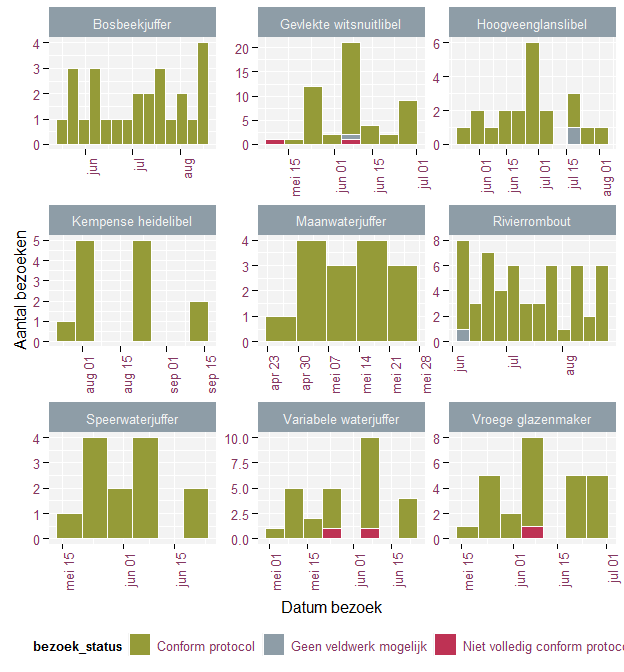

### 3.2.3 Afwijkingen van het protocol

De volgende tabel geeft een overzicht van de afwijkingen van het protocol.

| meetnet | datum | locatie | bezoek status | opmerkingen |
| --- | --- | --- | --- | --- |
| Gevlekte witsnuitlibel | 2018-06-04 | Buitengoor | Geen veldwerk mogelijk | Plasjes waren hier te droog owv de langdurige droogte. Geen Witsnuiten en de rest van het seizoen geen meer verwacht. |
| Gevlekte witsnuitlibel | 2018-05-09 | Turfven | Niet volledig conform protocol | te vroeg in seizoen, enkel gedeelte van terrein bezocht |
| Gevlekte witsnuitlibel | 2018-06-06 | Zegge | Niet volledig conform protocol | vrij laat op de dag uitgevoerd, temperatuur nog steeds 28°C |
| Hoogveenglanslibel | 2018-07-17 | Buitengoor oost west | Geen veldwerk mogelijk | Reeds bij het eerste bezoek was er bijna geen water meer aanwezig in de bewuste plas dus een tweede bezoek conform protocol brengen was niet mogelijk. Op 17/07 nog eens gaan kijken. |
| Rivierrombout | 2018-06-10 | Stelen brug - noord | Geen veldwerk mogelijk | afgesloten i v m de werken aan de nieuwe brug( de volledige omgeving) |
| Variabele waterjuffer | 2018-05-26 | Kallo Groot Rietveld | Niet volledig conform protocol | Slechts een klein gedeelte van de oever geschikt om te tellen, veel begroeiing. Transect bestaat uit twee delen |
| Variabele waterjuffer | 2018-06-09 | Kallo Groot Rietveld | Niet volledig conform protocol | transect is korter |
| Vroege glazenmaker | 2018-06-10 | Kallo Groot Rietveld | Niet volledig conform protocol | Rond het broedeiland op de vlakte van zwijndrecht ligt een brede gracht. Dit is binnen het afgebakende gebied de enige locatie die in aanmerking komt voor tellen vroege glazenmaker. Elders is er geen … |